# Matplotlib_intro

# Object Oriented Method

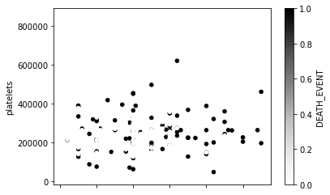

```python
over_forty.plot(kind='scatter', x='age',
                 y='platelets',
               c = 'DEATH_EVENT');
```

In scatter plot there is third parameter which does color-coding on the basis of suspectibility. over_40.plot(kind=scatter, x=age,y=chol, c =target) c is showing suspectibility of disease wrt occurence.

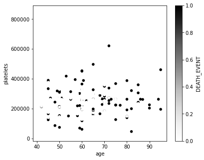

```python
figure, ax=plt.subplots(figsize=(6,5))
over_forty.plot(kind='scatter', x='age',
                 y='platelets',
               c = 'DEATH_EVENT',ax=ax);
```

If ponder upon the graph, it can be seen that x axis is more defined. Therefore OO is better than py.

ax is Base class for subplots, which are :class:`Axes` instances with additional methods to facilitate generating and manipulating a set of :class:`Axes` within a figure.

In other words, assigned data to to axes and to suspectibility variable is given to ax which after that save and plot it.

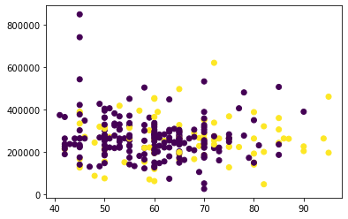

```python
#Creating figure
figure, sub_plot=plt.subplots(figsize=(6,4))
#Plotting Data
sub_plot.scatter(x=over_forty['age'],
          y=over_forty['platelets'],
          c= over_forty['DEATH_EVENT'], )
```

above graph DOES NOT HAVE NAME Of AXIS, IT WOULD BE GIVEN MANUALLY in this method of "ax.scatter" while in previous method column name is only given which not only plot data but also gives name to axis and to label c.

Customization

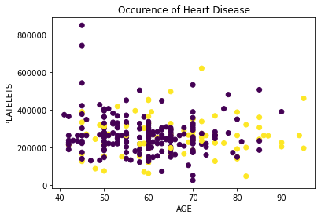

```python
#Creating figure
figure, ax=plt.subplots(figsize=(6,4))# here variable must be ax.
#Plotting Data
sub_plot=ax.scatter(x=over_forty['age'],
          y=over_forty['platelets'],
          c= over_forty['DEATH_EVENT'], ) # IN THIS FRAMEWORK IT DOES NOT HAVE GIVEN NAME TO AXIS, IT WOULD BE GIVEN MANUALLY
#Customization
ax.set(title = 'Occurence of Heart Disease', xlabel='AGE', ylabel='PLATELETS' );
```

Setting Legend

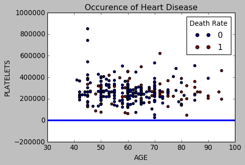

```python
#Creating figure
figure, ax=plt.subplots(figsize=(6,4))
#Plotting Data
sub_plot=ax.scatter(x=over_forty['age'],
          y=over_forty['platelets'],
          c= over_forty['DEATH_EVENT'], )
#Customization
ax.set(title = 'Occurence of Heart Disease', xlabel='AGE', ylabel='PLATELETS' );
#setting Legend
ax.legend(*sub_plot.legend_elements(), title='Death Rate'); #must place *.
#Meanline: to show mean value of any column on y-axis.
ax.axhline(y=over_forty['creatinine_phosphokinase'].mean(), linestyle='-', linewidth=3);
```

In last line of above code *subplot.legendelement is directing the legend to sub_plot to get given values to c, which is called legend, DEATH- EVENT IS GIVEN.

```python
#ejection_fraction	high_blood_pressure	platelets	serum_creatinine	serum_sodium
```

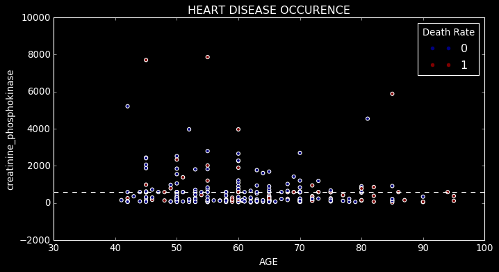

```python
figure, plot1=plt.subplots(figsize=(10,5))
plotting=plot1.scatter(x=over_forty['age'], y=over_forty['creatinine_phosphokinase'],c=over_forty['DEATH_EVENT'])
plot1.set(title='HEART DISEASE OCCURENCE', xlabel='AGE', ylabel='creatinine_phosphokinase');
plot1.legend(*plotting.legend_elements(), title= 'Death Rate' )
plot1.axhline(y = over_forty['creatinine_phosphokinase'].mean(),linestyle='--')
plt.style.use('dark_background')
```

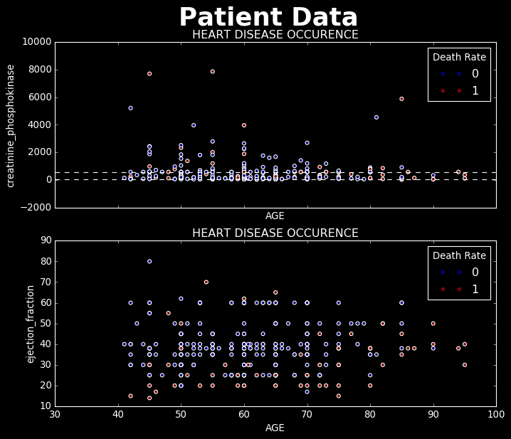

```python
#creating plot area
figure, (plot1,plot2)=plt.subplots(nrows=2, ncols=1, figsize=(10,8), sharex=True) #sharex:to share x axis values.

#ADDING DATA TO PLOTS
plotting1=plot1.scatter(x=over_forty['age'], y=over_forty['creatinine_phosphokinase'],c=over_forty['DEATH_EVENT'])
plotting2=plot2.scatter(x=over_forty['age'], y=over_forty['ejection_fraction'], c=over_forty['DEATH_EVENT'])

#CUSTOMIZATION
plot1.set(title='HEART DISEASE OCCURENCE', xlabel='AGE', ylabel='creatinine_phosphokinase');
plot2.set(title='HEART DISEASE OCCURENCE', xlabel='AGE', ylabel='ejection_fraction')

#Adding Legend
plot1.legend(*plotting1.legend_elements(), title= 'Death Rate' )
plot2.legend(*plotting2.legend_elements(), title = 'Death Rate')

#Meanline
plot1.axhline(y = over_forty['creatinine_phosphokinase'].mean(),linestyle='--')
plot1.axhline(y = over_forty['ejection_fraction'].mean(),linestyle='--')

#Giving style to fig
plt.style.use('dark_background')

#Naming the fig
figure.suptitle('Patient Data', fontsize=32, fontweight='bold')

#Saving the fig
figure.savefig('patient_data_report.png')
```

```python
over_forty
```

|  | age | anaemia | creatinine_phosphokinase | diabetes | ejection_fraction | high_blood_pressure | platelets | serum_creatinine | serum_sodium | sex | smoking | time | DEATH_EVENT |
| --- | --- | --- | --- | --- | --- | --- | --- | --- | --- | --- | --- | --- | --- |
| 0 | 75.0 | 0 | 582 | 0 | 20 | 1 | 265000.00 | 1.9 | 130 | 1 | 0 | 4 | 1 |
| 1 | 55.0 | 0 | 7861 | 0 | 38 | 0 | 263358.03 | 1.1 | 136 | 1 | 0 | 6 | 1 |
| 2 | 65.0 | 0 | 146 | 0 | 20 | 0 | 162000.00 | 1.3 | 129 | 1 | 1 | 7 | 1 |
| 3 | 50.0 | 1 | 111 | 0 | 20 | 0 | 210000.00 | 1.9 | 137 | 1 | 0 | 7 | 1 |
| 4 | 65.0 | 1 | 160 | 1 | 20 | 0 | 327000.00 | 2.7 | 116 | 0 | 0 | 8 | 1 |
| ... | ... | ... | ... | ... | ... | ... | ... | ... | ... | ... | ... | ... | ... |
| 294 | 62.0 | 0 | 61 | 1 | 38 | 1 | 155000.00 | 1.1 | 143 | 1 | 1 | 270 | 0 |
| 295 | 55.0 | 0 | 1820 | 0 | 38 | 0 | 270000.00 | 1.2 | 139 | 0 | 0 | 271 | 0 |
| 296 | 45.0 | 0 | 2060 | 1 | 60 | 0 | 742000.00 | 0.8 | 138 | 0 | 0 | 278 | 0 |
| 297 | 45.0 | 0 | 2413 | 0 | 38 | 0 | 140000.00 | 1.4 | 140 | 1 | 1 | 280 | 0 |
| 298 | 50.0 | 0 | 196 | 0 | 45 | 0 | 395000.00 | 1.6 | 136 | 1 | 1 | 285 | 0 |

292 rows × 13 columns